# RLab 05 – Simple Linear Regression Model

Roshan Thapa Magar

2025-10-20

# Introduction

This lab explores simple linear regression using the `Salaries` dataset from the `carData` package. We’ll examine relationships between faculty salaries and various predictors, including years since PhD, years of service, rank, discipline, and sex.

## Question 0

This question comes from exercises in section 23.2.1: One challenge with performing numerical optimization is that it’s only guaranteed to find one local optimum. What’s the problem with optimizing a three parameter model like this?

```r
model1 <- function(a, data) {
  a[1] + data$x * a[2] + a[3]
}
```

**Answer to Question 0**

This model has too many parameters. Linear regression only needs two (intercept and slope), but this has three. Both a[1] and a[3] are constant terms, creating redundancy. The computer can’t find the best values because there are infinitely many combinations that work.

# Data Exploration

```r
library(carData)
library(tidyverse)
library(modelr)
```

```r
head(Salaries)
```

```
##        rank discipline yrs.since.phd yrs.service  sex salary
## 1      Prof          B            19          18 Male 139750
## 2      Prof          B            20          16 Male 173200
## 3  AsstProf          B             4           3 Male  79750
## 4      Prof          B            45          39 Male 115000
## 5      Prof          B            40          41 Male 141500
## 6 AssocProf          B             6           6 Male  97000
```

The dataset contains 397 faculty members with variables: - `rank`: Academic rank (AsstProf, AssocProf, Prof) - `discipline`: Field of study (A or B) - `yrs.since.phd`: Years since PhD - `yrs.service`: Years of service - `sex`: Gender (Male, Female) - `salary`: Annual salary in dollars

# Scatterplots to Explore Data Sets

## Scatterplots with the `pairs` Command

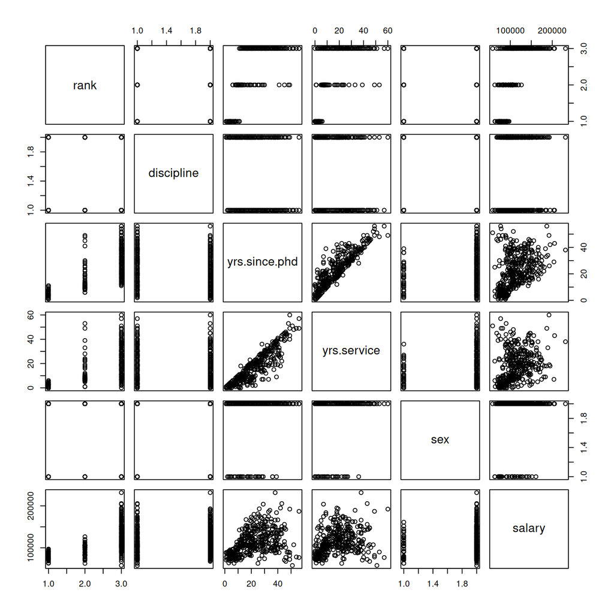

```r
pairs(Salaries)
```

The pairs plot shows relationships between all variables. Key observations: - Strong positive correlation between `yrs.since.phd` and `yrs.service` - Clear salary differences by rank - Potential gender differences in salary

## Scatterplots with `ggplot`

### Salary vs Years Since PhD

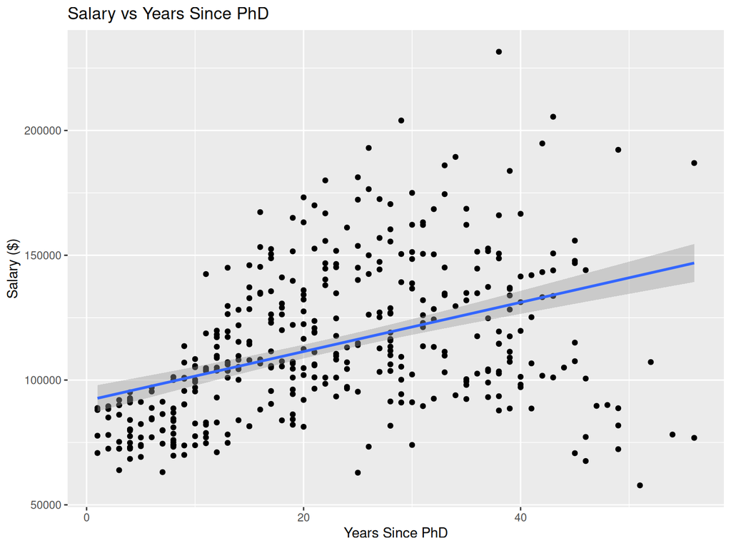

```r
Salaries %>%
  ggplot() +
  geom_point(mapping=aes(x=yrs.since.phd, y=salary)) +
  stat_smooth(mapping=aes(x=yrs.since.phd, y=salary), method="lm") +
  labs(title="Salary vs Years Since PhD",
       x="Years Since PhD",
       y="Salary ($)")
```

### Salary vs Years of Service

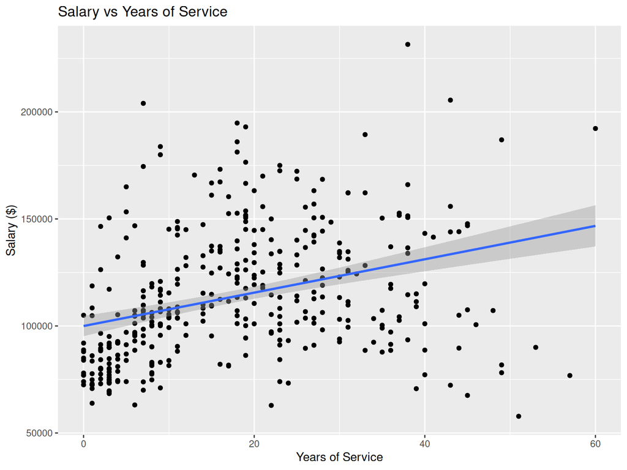

```r
Salaries %>%
  ggplot() +
  geom_point(mapping=aes(x=yrs.service, y=salary)) +
  stat_smooth(mapping=aes(x=yrs.service, y=salary), method="lm") +
  labs(title="Salary vs Years of Service",
       x="Years of Service",
       y="Salary ($)")
```

### Salary by Categorical Variables

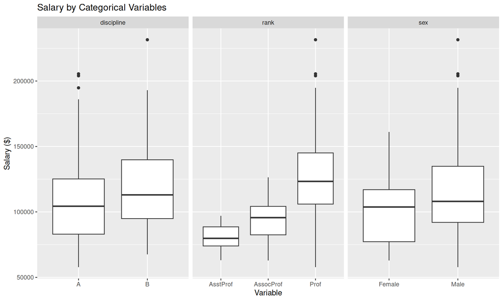

```r
Salaries %>%
  pivot_longer(c(rank, discipline, sex), names_to="xvar", values_to="xvalue") %>%
  ggplot() +
  geom_boxplot(mapping=aes(x=xvalue, y=salary)) +
  facet_wrap(facets="xvar", scales="free_x") +
  labs(title="Salary by Categorical Variables",
       x="Variable",
       y="Salary ($)")
```

### Gender Differences in Salary vs Years Since PhD

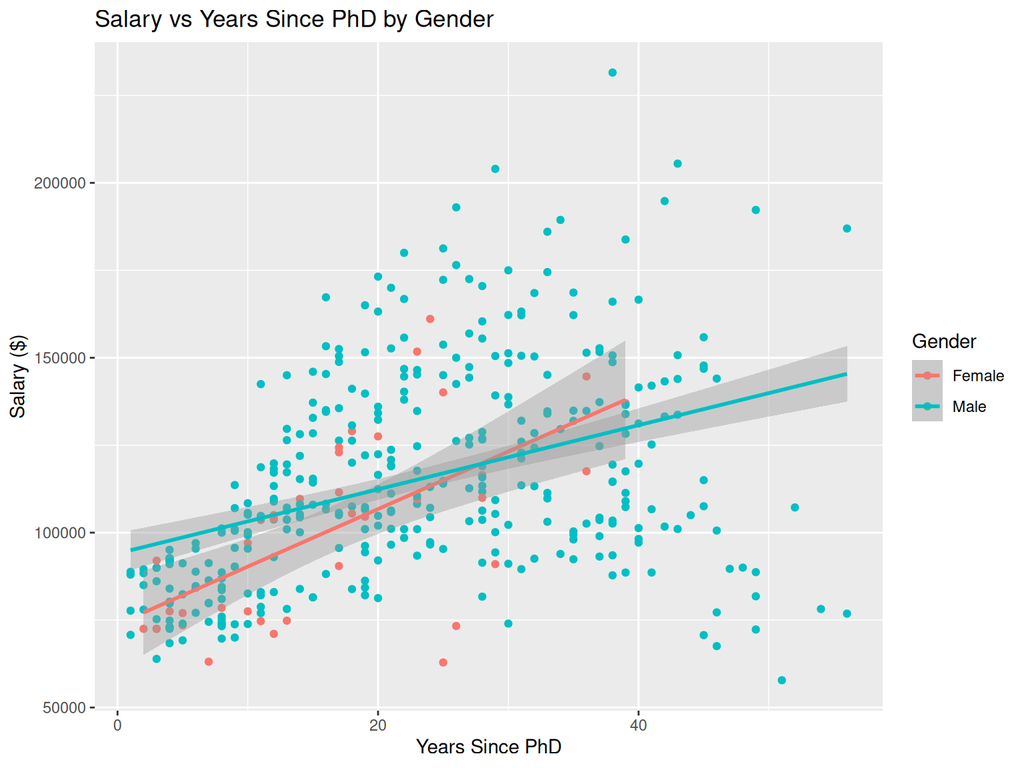

```r
Salaries %>%
  ggplot() +
  geom_point(mapping=aes(x=yrs.since.phd, y=salary, color=sex)) +
  stat_smooth(mapping=aes(x=yrs.since.phd, y=salary, color=sex), method="lm") +
  labs(title="Salary vs Years Since PhD by Gender",
       x="Years Since PhD",
       y="Salary ($)",
       color="Gender")
```

### Question 1 Analysis

**a)** Strong positive relationship between years of service and years since PhD. More years since PhD means more years of service since people start working after their degree.

**c)** Years since PhD has stronger connection to salary than years of service. The salary vs years since PhD plot shows a clearer straight line pattern.

**d)** Least helpful graph shows categorical variables like rank vs discipline. These are just categories, so plotting them against each other doesn’t show relationships.

### Question 2: Gender Analysis (Limited to <40 years since PhD)

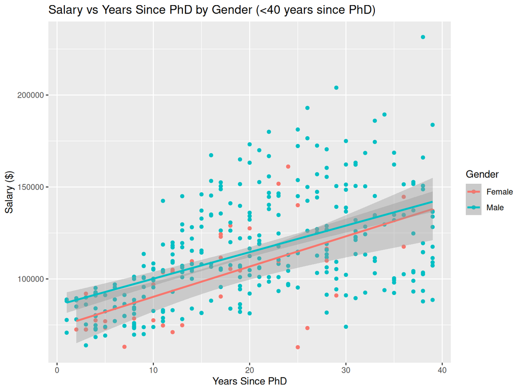

```r
Salaries %>%
  filter(yrs.since.phd < 40) %>%
  ggplot() +
  geom_point(mapping=aes(x=yrs.since.phd, y=salary, color=sex)) +
  stat_smooth(mapping=aes(x=yrs.since.phd, y=salary, color=sex), method="lm") +
  labs(title="Salary vs Years Since PhD by Gender (<40 years since PhD)",
       x="Years Since PhD",
       y="Salary ($)",
       color="Gender")
```

**a)** After limiting to faculty with <40 years since PhD, there is a pay difference. Women (red line) consistently make less than men (blue line) with similar experience.

# The Linear Correlation Coefficient

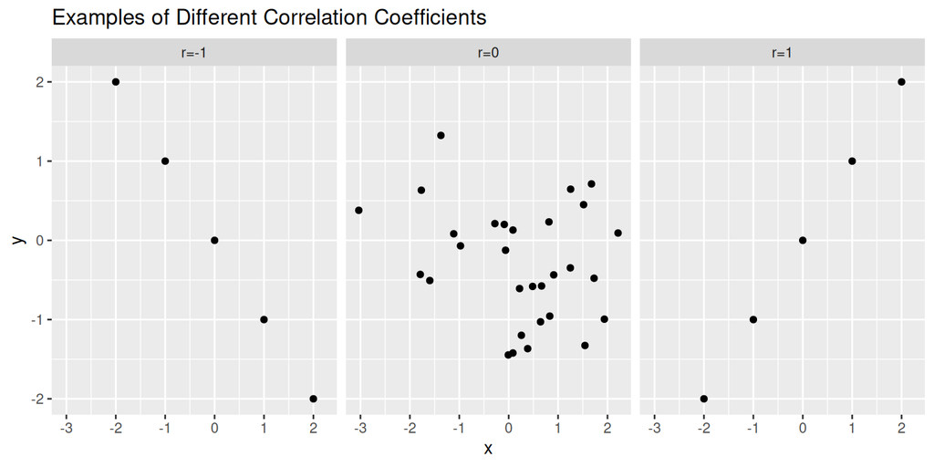

```r
# Create correlation examples
df = data.frame(x=c(-2:2, rnorm(30), -2:2),
                y=c(2:(-2), rnorm(30), -2:2),
                r = c(rep("r=-1", 5), rep("r=0", 30), rep("r=1", 5)))
ggplot(data=df) +
  geom_point(mapping=aes(x=x, y=y)) +
  facet_wrap(facets="r") +
  labs(title="Examples of Different Correlation Coefficients")
```

## Correlation Analysis

```r
cor(Salaries$salary, Salaries$yrs.since.phd)
```

```
## [1] 0.4192311
```

```r
Salaries %>%
  select(salary, yrs.since.phd) %>%
  cor()
```

```
##                  salary yrs.since.phd
## salary        1.0000000     0.4192311
## yrs.since.phd 0.4192311     1.0000000
```

```r
Salaries %>%
  select(salary, yrs.since.phd, yrs.service) %>%
  cor()
```

```
##                  salary yrs.since.phd yrs.service
## salary        1.0000000     0.4192311   0.3347447
## yrs.since.phd 0.4192311     1.0000000   0.9096491
## yrs.service   0.3347447     0.9096491   1.0000000
```

# Regression Analysis

## Simple Linear Regression: Salary vs Years Since PhD

```r
salary_mod <- lm(salary ~ yrs.since.phd, data=Salaries)
summary(salary_mod)
```

```
##
## Call:
## lm(formula = salary ~ yrs.since.phd, data = Salaries)
##
## Residuals:
##    Min     1Q Median     3Q    Max
## -84171 -19432  -2858  16086 102383
##
## Coefficients:
##               Estimate Std. Error t value Pr(>|t|)
## (Intercept)    91718.7     2765.8  33.162   <2e-16 ***
## yrs.since.phd    985.3      107.4   9.177   <2e-16 ***
## ---
## Signif. codes:  0 '***' 0.001 '**' 0.01 '*' 0.05 '.' 0.1 ' ' 1
##
## Residual standard error: 27530 on 395 degrees of freedom
## Multiple R-squared:  0.1758, Adjusted R-squared:  0.1737
## F-statistic: 84.23 on 1 and 395 DF,  p-value: < 2.2e-16
```

```r
coef(salary_mod)
```

```
##   (Intercept) yrs.since.phd
##    91718.6854      985.3421
```

**Model Equation:** Salary = 91,718.69 + 985.34 × Years Since PhD

- **R² = 0.176**: The model explains 17.6% of salary variation
- **p-value < 2.2e-16**: Highly significant relationship
- **Residual SE = 27,530**: Average prediction error

## Visualizing Predictions and Residuals

```r
head(Salaries %>% add_predictions(salary_mod))
```

```
##        rank discipline yrs.since.phd yrs.service  sex salary      pred
## 1      Prof          B            19          18 Male 139750 110440.19
## 2      Prof          B            20          16 Male 173200 111425.53
## 3  AsstProf          B             4           3 Male  79750  95660.05
## 4      Prof          B            45          39 Male 115000 136059.08
## 5      Prof          B            40          41 Male 141500 131132.37
## 6 AssocProf          B             6           6 Male  97000  97630.74
```

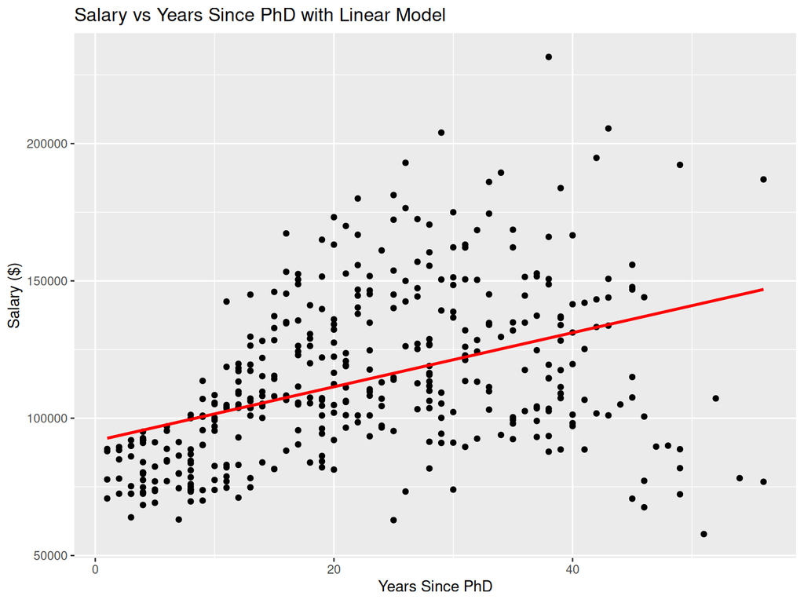

```r
Salaries %>%
  add_predictions(salary_mod) %>%
  ggplot() +
  geom_point(mapping=aes(x=yrs.since.phd, y=salary)) +
  geom_line(mapping=aes(x=yrs.since.phd, y=pred), color="red", size=1) +
  labs(title="Salary vs Years Since PhD with Linear Model",
       x="Years Since PhD",
       y="Salary ($)")
```

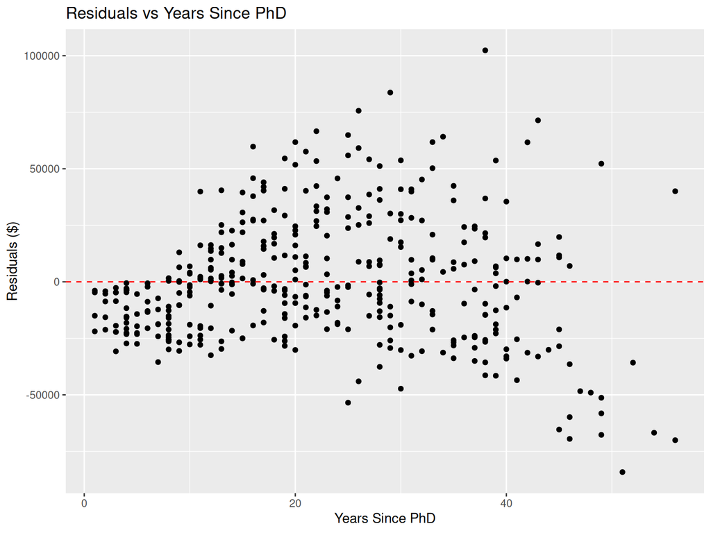

```r
Salaries %>%
  add_residuals(salary_mod) %>%
  ggplot() +
  geom_point(mapping = aes(x=yrs.since.phd, y=resid)) +
  geom_hline(yintercept = 0, color="red", linetype="dashed") +
  labs(title="Residuals vs Years Since PhD",
       x="Years Since PhD",
       y="Residuals ($)")
```

The residual plot shows some curvature, suggesting the linear model may not capture all patterns in the data.

## Categorical Predictors: Salary vs Rank

```r
salary_mod2 <- lm(salary ~ rank, data=Salaries)
coef(salary_mod2)
```

```
##   (Intercept) rankAssocProf      rankProf
##      80775.99      13100.45      45996.12
```

**Model Interpretation:** - **Assistant Professor (base)**: $80,776 - **Associate Professor**: $80,776 + $13,100 = $93,876 - **Full Professor**: $80,776 + $45,996 = $126,772

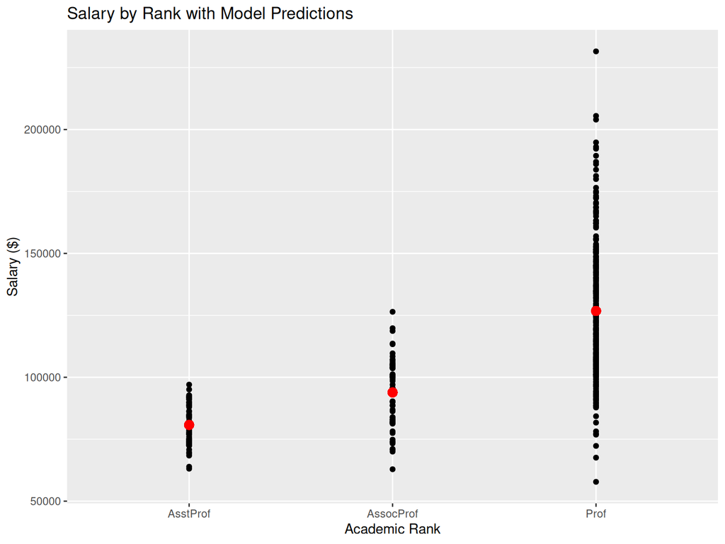

```r
Salaries %>%
  add_predictions(salary_mod2) %>%
  ggplot() +
  geom_point(mapping = aes(x=rank, y=salary)) +
  geom_point(mapping = aes(x=rank, y=pred), color="red", size=3) +
  labs(title="Salary by Rank with Model Predictions",
       x="Academic Rank",
       y="Salary ($)")
```

## Question 4: Salary vs Years of Service

```r
salary_mod_service <- lm(salary ~ yrs.service, data=Salaries)
summary(salary_mod_service)
```

```
##
## Call:
## lm(formula = salary ~ yrs.service, data = Salaries)
##
## Residuals:
##    Min     1Q Median     3Q    Max
## -81933 -20511  -3776  16417 101947
##
## Coefficients:
##             Estimate Std. Error t value Pr(>|t|)
## (Intercept)  99974.7     2416.6   41.37  < 2e-16 ***
## yrs.service    779.6      110.4    7.06 7.53e-12 ***
## ---
## Signif. codes:  0 '***' 0.001 '**' 0.01 '*' 0.05 '.' 0.1 ' ' 1
##
## Residual standard error: 28580 on 395 degrees of freedom
## Multiple R-squared:  0.1121, Adjusted R-squared:  0.1098
## F-statistic: 49.85 on 1 and 395 DF,  p-value: 7.529e-12
```

```r
coef(salary_mod_service)
```

```
## (Intercept) yrs.service
##  99974.6529    779.5691
```

**Model Equation:** Salary = 99,974.65 + 779.57 × Years of Service

- **R² = 0.112**: Only explains 11.2% of salary variation
- **p-value = 7.53e-12**: Statistically significant but weak relationship

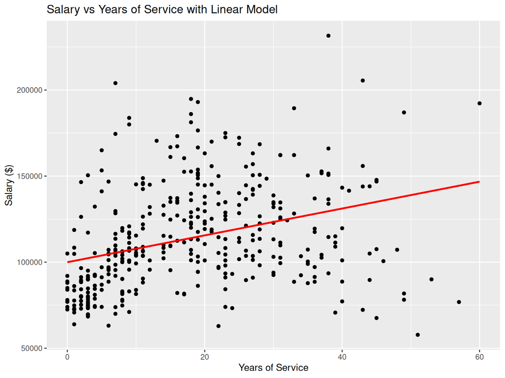

```r
Salaries %>%
  add_predictions(salary_mod_service) %>%
  ggplot() +
  geom_point(mapping=aes(x=yrs.service, y=salary)) +
  geom_line(mapping=aes(x=yrs.service, y=pred), color="red", size=1) +
  labs(title="Salary vs Years of Service with Linear Model",
       x="Years of Service",
       y="Salary ($)")
```

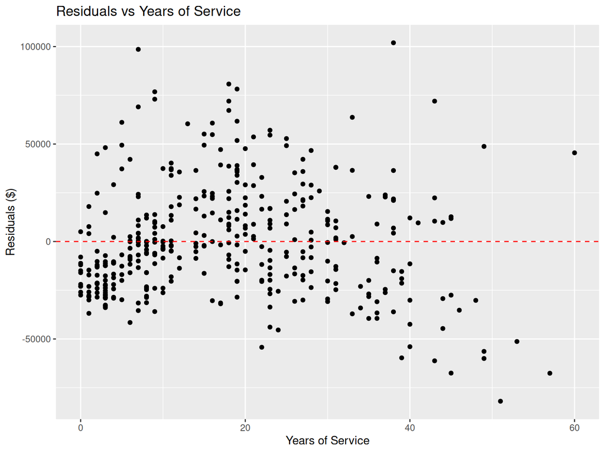

```r
Salaries %>%
  add_residuals(salary_mod_service) %>%
  ggplot() +
  geom_point(mapping = aes(x=yrs.service, y=resid)) +
  geom_hline(yintercept = 0, color="red", linetype="dashed") +
  labs(title="Residuals vs Years of Service",
       x="Years of Service",
       y="Residuals ($)")
```

### Question 4 Analysis

The linear fit is **not good**. The residual plot shows a curved pattern instead of random dots around zero. The model over-predicts for people with few/many years of service but under-predicts for those in the middle range. We need a curved model, not a straight line.

# Summary and Conclusions

## Key Findings

1. **Years Since PhD vs Years of Service**: Strong positive correlation (r = 0.91), with a clear diagonal boundary due to logical constraints.
2. **Salary Relationships**:
   - **Years Since PhD**: Moderate positive correlation (r = 0.42), explains 17.6% of salary variation
   - **Years of Service**: Weaker positive correlation (r = 0.33), explains only 11.2% of salary variation
   - **Academic Rank**: Strongest predictor with clear salary differences between ranks
3. **Gender Differences**: After controlling for years since PhD (<40 years), women consistently earn less than men with similar experience.
4. **Model Quality**:
   - **Years Since PhD model**: Reasonable fit with some curvature in residuals
   - **Years of Service model**: Poor fit with clear non-linear patterns in residuals

## Statistical Insights

- The relationship between salary and years of service appears non-linear, suggesting diminishing returns or other complex patterns
- Years since PhD provides better linear prediction than years of service
- Academic rank shows the clearest salary stratification
- Gender pay differences persist even after controlling for experience

## Recommendations

1. Consider non-linear models for years of service (polynomial or spline regression)
2. Investigate additional predictors that might explain salary variation
3. Further examine gender pay differences with more sophisticated models
4. Consider interaction effects between variables (e.g., rank × years since PhD)

This analysis demonstrates the importance of both visual exploration and statistical modeling in understanding complex relationships in salary data.